# Lab 07-A Regression in Statistics

## RE 519 Data Analytics and Visualization | Autumn 2026

- Lab 07 Regression in Statistics
  - A Simple Linear Regression
    - Check Assumptions
    - Adjustment to the Regression
    - Interactions and Non-linear Variables
    - Compare Models
    - Prediction
  - A Logistic Regression
    - Check Assumptions of Logistic Regression
    - Adjustment to the Logistic Regression
    - Compare Logistic Models
    - Prediction with Logistic Regression
    - 📚 TODO: Explain the Results of Linear Regression
    - 📚 TODO: Apply and Interpret Logistic Regression (HMDA)
    - 📖 Optional: Logistic Regression in a Research Paper (Not Graded)
  - Acknowledgement

In Lab 7, we will go back to the **King County sales** data from maintained by [Andy Krause](https://www.andykrause.com/index.html) at Zillow. You can find the datasets and Readme file in [this repository](https://github.com/andykrause/kingCoData).

Lab 7 comes in **two parts, released separately**. This is **Part A**, where we use classical regression, which considers more on the model specification, assumptions, and parameter interpretation. We cover two models: **linear regression** for a continuous outcome (King County sale prices) and **logistic regression** for a binary outcome (mortgage denial in the Boston HMDA data). **Part B** (released after the machine learning lecture) still uses regression but under the context of machine learning, where we care about the prediction accuracy on unseen test dataset. A seminal paper discusses the **two cultures in statistical modeling**: [Statistical Modeling: The Two Cultures. Leo Breiman. 2001.](https://projecteuclid.org/journals/statistical-science/volume-16/issue-3/Statistical-Modeling--The-Two-Cultures-with-comments-and-a/10.1214/ss/1009213726.full)

From Lab 4, the use of any generative AI tool (ChatGPT, Copilot, etc.) is **allowed** for coding assignments. But, I still encourage you to write codes by yourself and use AI tools as a way to debug and explore new knowledge. More information about [Academic Integrity](https://www.yuehaoyu.com/data-analytics-visualization/syllabus/#academic-integrity) and [the Use of AI](https://www.yuehaoyu.com/data-analytics-visualization/syllabus/#use-of-ai).

# Lab 07 Regression in Statistics

```r
# --- install packages (run once, then keep these lines commented out) ---
#install.packages("modelsummary") # formats regression tables
#install.packages("devtools")     # lets us install packages from GitHub (needed on Windows)
#devtools::install_github('andykrause/kingCoData') # the King County sales data package

# --- load packages (run every time you open R) ---
library('tidyverse')   # data wrangling (dplyr, tidyr) and plotting (ggplot2)
library(modelsummary)  # side by side regression result tables
library('kingCoData')  # King County home sales data
```

```r
data(kingco_sales) # load the sale data
# only select the sales in 2023
sales <- kingco_sales %>%
  filter(sale_date >= as.Date("2023-01-01") & sale_date <= as.Date("2023-12-31"))
```

## A Simple Linear Regression

#### Checking Correlation

Correlation ($r$) measures the strength and direction of a linear relationship between two variables. The most common one for continuous numeric data is [**Pearson correlation**](https://en.wikipedia.org/wiki/Pearson_correlation_coefficient), which ranges from -1 to 1.

- +1 Perfect positive correlation
- 0 No linear relationship
- –1 Perfect negative correlation

```r
# Pearson correlation matrix for four numeric variables
# each cell is the correlation (r) between the row and the column variable
cor(sales[, c("sale_price", "sqft", "year_built", "condition")])
```

```
##             sale_price        sqft   year_built   condition
## sale_price 1.000000000  0.53927682  0.005699814  0.01146259
## sqft       0.539276825  1.00000000  0.295748914 -0.06728411
## year_built 0.005699814  0.29574891  1.000000000 -0.36754450
## condition  0.011462589 -0.06728411 -0.367544504  1.00000000
```

#### Scatterplots

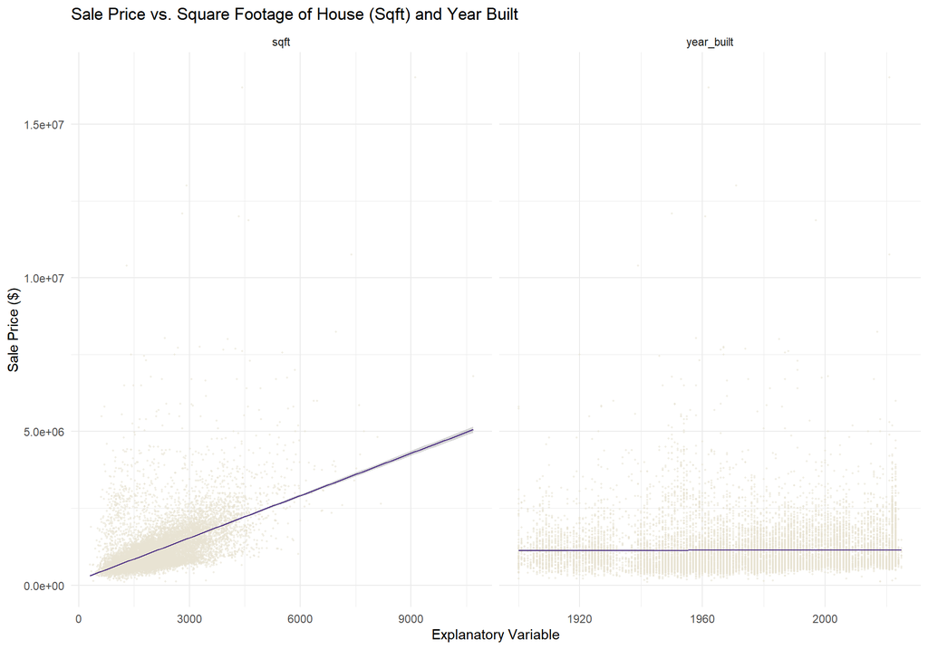

```r
# reshape from wide to long: one row per (house, variable) pair
# this lets us draw both scatterplots with one ggplot call using facets
sales_long <- sales |>
  pivot_longer(
    cols = c(sqft, year_built), # the two X variables we want to plot
    names_to = "variable",      # new column holding the variable name
    values_to = "xvalue"        # new column holding the X value
  )

ggplot(sales_long, aes(x = xvalue, y = sale_price)) +
  geom_point(size = 0.3, alpha = 0.5, color = "#e8e3d3") +   # one point per sale
  geom_smooth(linewidth = 0.5, method = "lm", formula = "y~x",
              color = "#4b2e83") +                          # straight OLS line
  facet_wrap(~ variable, scales = "free_x") +  # one panel per X, each with its own x axis
  labs(
    x = "Explanatory Variable",
    y = "Sale Price ($)",
    title = "Sale Price vs. Square Footage of House (Sqft) and Year Built"
  ) +
  theme_minimal()
```

#### Fitting the Model

Starting to fit a regression, you define a family of models that express a precise, but generic, pattern that you want to capture. For example, the pattern might be a straight line, or a quadratic curve. You will express the model family as an equation like $y=β0+β1x$ or $y=β0+β1x2$. Here, $x$ and $y$ are known variables from your data, and $β0$ and $β1$ are parameters that can vary to capture different patterns.

```r
# lm() fits a linear model by ordinary least squares (OLS)
# formula: Y ~ X1 + X2; R adds the intercept for us
simple_lm <- lm(data = sales, sale_price ~ sqft + year_built)
```

We can check the results using `summary()` (result table) and `confint()` (confidence intervals).

```r
summary(simple_lm) # coefficients, standard errors, t values, p values, R-squared
```

```
##
## Call:
## lm(formula = sale_price ~ sqft + year_built, data = sales)
##
## Residuals:
##      Min       1Q   Median       3Q      Max
## -1845377  -321881   -93956   172424 13848369
##
## Coefficients:
##               Estimate Std. Error t value Pr(>|t|)
## (Intercept) 8023953.22  325413.85   24.66   <2e-16 ***
## sqft            501.08       5.93   84.50   <2e-16 ***
## year_built    -4022.48     166.39  -24.17   <2e-16 ***
## ---
## Signif. codes:  0 '***' 0.001 '**' 0.01 '*' 0.05 '.' 0.1 ' ' 1
##
## Residual standard error: 645400 on 15406 degrees of freedom
## Multiple R-squared:  0.3167, Adjusted R-squared:  0.3166
## F-statistic:  3571 on 2 and 15406 DF,  p-value: < 2.2e-16
```

```r
confint(simple_lm) # 95% confidence interval for each coefficient
```

```
##                    2.5 %       97.5 %
## (Intercept) 7386103.6761 8661802.7661
## sqft            489.4558     512.7013
## year_built    -4348.6282   -3696.3264
```

How to read the tables?

[figure not shown]

Results from R and Interpretations

**Click to view additional notes on reading the results**

**Hypothesis**: The model test if $Y$ is associated with $X$. The null hypothesis $H0$ is that there is no linear relationship between the response variable and the explanatory variable(s), and the alternative hypothesis $H1$ is that there is relationship.

**Estimate and standard error**:In the model, estimate is the estimation of coefficient $β$, std.error is the standard error for estimation. The standard error of the coefficient is an estimate of the standard deviation of the coefficient $β$. In effect, it is telling us how much uncertainty there is with our coefficient. The standard error is often used to create confidence intervals.

**t-statistic**: The t-statistic is simply the coefficient divided by the standard error. In general, we want our coefficients to have large t-statistics, because it indicates that our standard error is small in comparison to our coefficient. Simply put, we are saying that the coefficient is $t$ standard errors away from zero.

**p-value**: If you see the variable has p value $≤0.05$, or you can also see the star next to $Pr(>|t|))$, we can say we reject the null hypothesis. In practice, any p-value below 0.05 is usually deemed as significant. What do we mean when we say significant? It means we are confident that the coefficient is not zero, meaning the coefficient does in fact add value to the model by helping to explain the variance within our dependent variable. **Note:** reading the stars this way only works for individual variables and not categorical variables.

**R-squared**: R-squared explains how much variation of y can be explained by the model. This is helpful for univariate regression, but starts to become fairly unhelpful for multivariate regression. We would look at adjusted R-squared, which penalizes complexity.

### Check Assumptions

For a normal linear model to be a good model, there are some conditions/assumptions that need to be fulfilled. The six below match the “OLS Assumptions in Plain Words” table from lecture:

1. **Linearity**: average $Y$ changes along a straight line in $X$. $Y$ can be described by a linear combination of $X$ (or transformations of $X$). You may log or square $X$, but not $β$.
2. **Random sample, independent errors**: each home is a fresh draw; one sale’s error tells us nothing about a neighbor’s. We are using time series and spatial data, so we are likely to violate this assumption.
3. **No perfect multicollinearity among X**: no $X$ is an exact copy or sum of other $X$s. Example: using all three scores as $X$ if total score = part A score + part B score.
4. **Zero conditional mean** $E[ε∣X]=0$: nothing left in the error moves with $X$; no important variable is left out. If it fails, we get omitted-variable bias and the slope is wrong.
5. **Equal variance (homoscedasticity)** $Var(ε∣X)=σ2$: errors spread the same way for cheap and expensive homes.
6. **Normal errors** $ε∼N(0,σ2)$: errors follow a bell curve.

How much each assumption buys you:

- **Assumptions 1–4** give *unbiased slopes* — right on average.
- **+ Assumption 5** makes OLS **BLUE** — the most precise linear unbiased estimator (Gauss–Markov).
- **+ Assumption 6** makes *p-values exact* even in a small sample, not just approximately.

If these assumptions are not met, the inference with the computed standard error is invalid. That is, if the assumptions are not met, the standard error should not be trusted, or should be computed using alternative methods.

The quickest way to check many assumptions is to use `plot(model)` and it will generated several key plots for us. We use `which` to specify the plot but in practice, you can generate them at the same time.

We will setup a ‘perfect’ model as the example to compare:

```r
set.seed(519) # fix the random numbers so everyone gets the same "perfect" model

# simulate data that meets every OLS assumption:
# a true straight line (3 + 2x) plus normal noise with constant spread
example_x <- seq(1, 100, by = 1)
example_y <- 3 + 2 * example_x + rnorm(100, mean = 0, sd = 2)
example_model <- lm(example_y ~ example_x)
```

#### Residuals vs Fitted

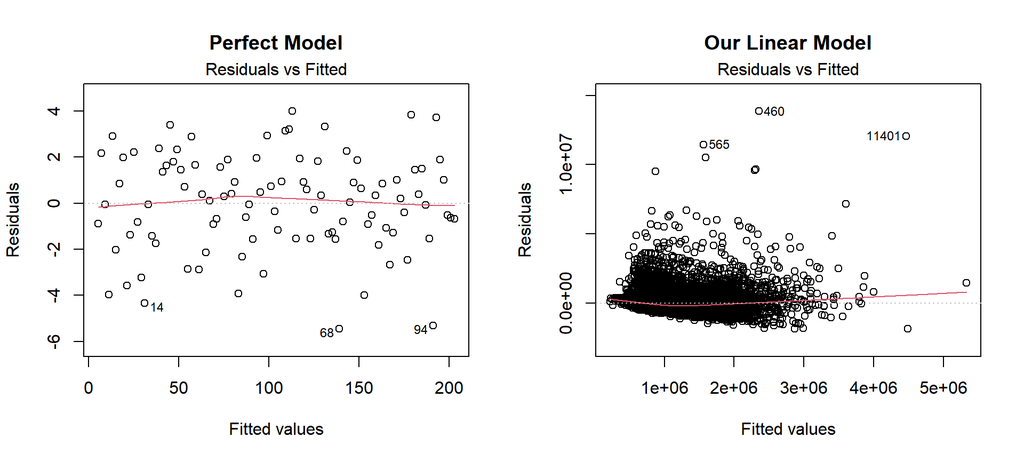

```r
par(mfrow = c(1, 2))  # put the next two plots side by side (1 row, 2 columns)

# which = 1 asks plot() for the Residuals vs Fitted panel only
plot(example_model, which = 1, main = "Perfect Model")
plot(simple_lm, which = 1, main = "Our Linear Model")
```

```r
par(mfrow = c(1, 1))  # reset to one plot per figure
```

**Horizontal Axis**: Fitted values (predicted values) from the regression model.

**Vertical Axis**: Residuals (the differences between the observed values and the predicted values).

**Interpretation**: This plot helps you check for linearity and homoscedasticity (equal variance of error terms). Ideally, you should see a horizontal red line (for linearity) and random scatter of points with no discernible pattern (for homoscedasticity). If there’s a pattern (e.g., a curve or fan shape), it suggests non-linearity or heteroscedasticity, which might indicate a problem with the model.

**In the perfect model**: points form an even band around 0 with no shape, and the red line stays flat. This is what “good” looks like.

**In our case**: the red line stays close to 0 but bends a little (slightly below 0 in the middle, rising above 0 at the highest fitted values), so there is mild nonlinearity. The bigger problem is the **fan shape**: the spread of residuals grows as fitted values grow, which breaks equal variance (Assumption 5). The residuals are also lopsided. Positive residuals reach about $14 million (sales 460, 565 and 11401), while negative residuals rarely go below $-2 million. In other words, the model badly underpredicts a few very expensive homes. Price data are often right skewed (long upper tail), and a log transformation of $Y$ is a common fix.

> **What this plot CANNOT tell you — Assumption 4 (zero conditional mean).** A flat red line here does **not** prove $E[ε∣X]=0$. By construction, OLS forces the residuals to average zero and to be uncorrelated with the included $X$s — so the residual plot will look “fine” even when an important variable has been left out. Zero conditional mean is about **research design and theory** (did we include the right controls, is $X$ exogenous?), not something a diagnostic plot can confirm. Omitted-variable bias cannot be detected by staring at residuals, and “more data never fixes it.”

#### Q–Q Plot

[Q-Q plots](https://library.virginia.edu/data/articles/understanding-q-q-plots) helps us to compare a set of data with normal distribution. If the data is perfectly normally distributed, it should follow the dash line.

- S-shaped curve: heavier tails or more peaked than the normal distribution (for example, a t-distribution).
- Curved upward or downward: skewness (the data are not symmetric).
- Clearly deviating from the straight line: Suggests the data are not normally distributed.

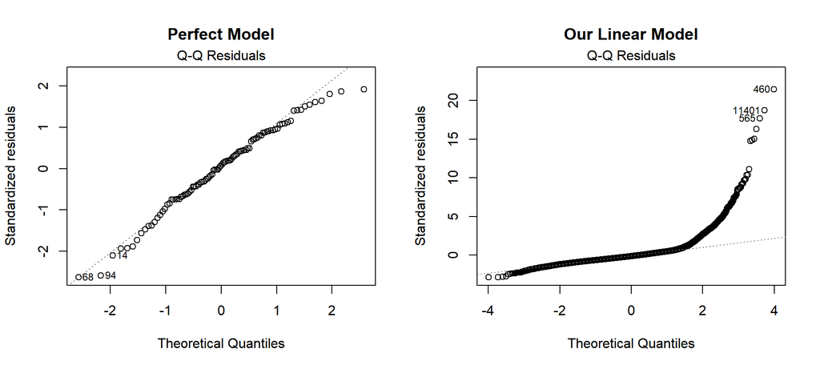

```r
par(mfrow = c(1, 2))  # two plots side by side

# which = 2 gives the normal Q-Q plot of standardized residuals
plot(example_model, which = 2, main = "Perfect Model")
plot(simple_lm, which = 2, main = "Our Linear Model")
```

```r
par(mfrow = c(1, 1))  # reset the layout
```

**In the perfect model**: points follow the dashed line closely, with only small wiggles at the ends. That is normal sampling noise.

**In our case**: the left half of the points sits close to the line, but from about 1.5 theoretical quantiles the points **curve sharply upward**, reaching standardized residuals above 20 (sales 460, 11401 and 565). A normal distribution would almost never produce a value beyond 4. This one sided upward curve means the residuals are **right skewed**: a long upper tail of homes that sold for far more than the model predicts. Assumption 6 (normal errors) fails. With over 15,000 sales, p values are still roughly correct because of the central limit theorem, but the extreme tail is a warning about outliers.

#### Residuals vs Leverage

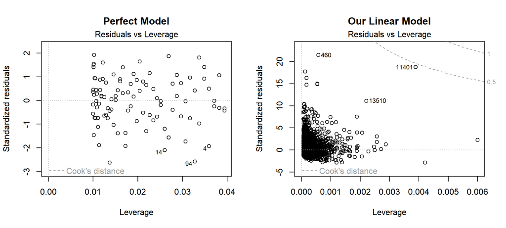

```r
par(mfrow = c(1, 2))  # two plots side by side

# which = 5 gives Residuals vs Leverage with Cook's distance contours
plot(example_model, which = 5, main = "Perfect Model")
plot(simple_lm, which = 5, main = "Our Linear Model")
```

```r
par(mfrow = c(1, 1))  # reset the layout
```

**Horizontal Axis**: Leverage (hat values). Leverage measures how **unusual an observation’s $X$ values are**, for example a very large or very old house. High leverage means a point *could* pull the line, but it does not mean it *does*.

**Vertical Axis**: Standardized residuals (residuals divided by their standard deviation).

**Interpretation**: This plot puts two ideas together. Points far above or below 0 are **outliers** (unusual $Y$ given $X$). Points far to the right have **high leverage** (unusual $X$). A point is **influential** when it is both, which means removing it would move the regression line noticeably. The gray dashed curves are **Cook’s distance** contours at 0.5 and 1. Points beyond those curves (top right or bottom right corners) are the ones to worry about. If no curve shows up in the plot, every point is far inside them.

**In the perfect model**: residuals stay between about -2 and 2, and leverage is small and similar for everyone (equally spaced $X$). No Cook’s contour is visible.

**In our case**: most sales sit near zero leverage, as expected with 15,409 observations. Sale **460** has a huge residual (about 21) but low leverage, so it is an outlier with limited influence. Sale **11401** has both a large residual (about 19) and higher leverage (a 9,110 sqft house), so it sits close to the Cook’s distance = 0.5 contour (its Cook’s D is 0.46). Sale **13510** is similar but smaller. Nothing crosses 0.5, so no single sale is strongly changing the line. But are these sales errors, and should we remove them? The next section shows how to decide.

#### Outliers, Leverage and Influence: Should We Remove Them?

It is tempting to delete any point that looks unusual. That is usually a **bad idea**. A careful decision has two parts: **metrics** to flag rows, and **judgment** to decide what to do with them.

**Step 1. Flag with metrics.** Each metric answers a different question ($n$ = number of observations, $k$ = number of coefficients including the intercept):

[output not shown]

```r
n <- nobs(simple_lm)          # number of observations used in the model
k <- length(coef(simple_lm))  # number of coefficients, including the intercept

# one row per sale with the three main influence measures
influence_lm <- data.frame(
  row      = 1:n,
  rstudent = rstudent(simple_lm),       # studentized residual
  leverage = hatvalues(simple_lm),      # hat value
  cooks_d  = cooks.distance(simple_lm)  # Cook's distance
)

# how many sales does each rule flag?
c(outlier_r3      = sum(abs(influence_lm$rstudent) > 3),
  leverage_3k_n   = sum(influence_lm$leverage > 3 * k / n),
  cooks_4_n       = sum(influence_lm$cooks_d > 4 / n),
  cooks_0.5       = sum(influence_lm$cooks_d > 0.5),
  dfbeta_sqft     = sum(abs(dfbetas(simple_lm)[, "sqft"]) > 2 / sqrt(n)))
```

```
##    outlier_r3 leverage_3k_n     cooks_4_n     cooks_0.5   dfbeta_sqft
##           282           275           678             0           772
```

With $n=15,409$, the “$4/n$” cutoff is only 0.00026, so it flags 678 sales. The loose rules flag hundreds of rows in a large dataset. They tell us **where to look**, not what to delete. Only the $0.5$ rule is strict, and it flags none.

**Step 2. Look at the flagged rows.** Is it a data error, or a real sale that the model cannot explain?

```r
# the five most influential sales, with a few columns that describe them
top5 <- order(influence_lm$cooks_d, decreasing = TRUE)[1:5]
cbind(influence_lm[top5, c("rstudent", "cooks_d")],
      sales[top5, c("sale_price", "sqft", "year_built", "city", "wfnt", "sale_warning")])
```

```
##       rstudent    cooks_d sale_price sqft year_built         city wfnt
## 11401 18.93853 0.45594692   16518888 9110       2021       MEDINA    0
## 13510 11.13919 0.09104044   10750000 7390       2021       MEDINA    0
## 460   21.79158 0.08860685   16200000 4430       1962      SEATTLE    6
## 1087  15.12836 0.04103089   12000000 4340       1961 YARROW POINT    6
## 9752  14.96125 0.03984449   11880000 4600       1997       MEDINA    6
##       sale_warning
## 11401
## 13510
## 460
## 1087
## 9752
```

These are **real luxury sales**, not typos. Sales 11401 and 13510 are new mansions in Medina (over 7,000 sqft, built in 2021). Sales 460, 1087 and 9752 are on the Lake Washington waterfront (`wfnt = 6` is the King County code for Lake Washington). None has an assessor sale warning (`sale_warning` is blank). They look like outliers because our model only knows size and age. It does not know about **waterfront, location or lot size**, which explain most of these prices.

**Step 3. Sensitivity analysis.** Refit the model without the flagged rows and see whether the conclusion changes.

```r
# refit without the 3 sales with the largest Cook's distance
top3 <- order(influence_lm$cooks_d, decreasing = TRUE)[1:3]
lm_drop3 <- update(simple_lm, data = sales[-top3, ])

# refit without every sale above the 4/n cutoff (the "mechanical" approach)
lm_drop4n <- update(simple_lm, data = sales[influence_lm$cooks_d <= 4 / n, ])

# compare coefficients, R-squared and sample size side by side
data.frame(
  model = c("All sales", "Drop top 3", "Drop Cook's D > 4/n"),
  sqft = c(coef(simple_lm)["sqft"], coef(lm_drop3)["sqft"], coef(lm_drop4n)["sqft"]),
  year_built = c(coef(simple_lm)["year_built"], coef(lm_drop3)["year_built"],
                 coef(lm_drop4n)["year_built"]),
  r_squared = c(summary(simple_lm)$r.squared, summary(lm_drop3)$r.squared,
                summary(lm_drop4n)$r.squared),
  n = c(nobs(simple_lm), nobs(lm_drop3), nobs(lm_drop4n))
)
```

```
##                 model     sqft year_built r_squared     n
## 1           All sales 501.0786  -4022.477 0.3167381 15409
## 2          Drop top 3 488.4522  -3957.888 0.3179086 15406
## 3 Drop Cook's D > 4/n 446.8977  -2304.808 0.4916941 14731
```

```r
# median price of the sales the 4/n rule would delete, vs all sales
median(sales$sale_price[influence_lm$cooks_d > 4 / n])
```

```
## [1] 3149000
```

```r
median(sales$sale_price)
```

```
## [1] 895000
```

Dropping the top three changes the `sqft` slope only a little (about $501 to $488 per sqft). Dropping all 678 rows above $4/n$ raises R-squared from 0.32 to 0.49, which *looks* like a better model. But the deleted sales have a median price of about $3.1 million, versus $895,000 overall. We did not improve the model; we **removed the expensive part of the market** and changed the population we describe.

**Step 4. Decide and report.**

- **Remove** a row only if it is a **data error** (impossible values, duplicate records, a sale price of $1) or it is **outside the population** you want to study (for example, a sale between family members, which is not an arm’s length market sale).
- **Keep** a real observation that the model cannot explain. Fix the **model** instead: transform $Y$ (log), add missing variables, or use a method that is less sensitive to extreme values (robust regression).
- **Report** what you did. If you remove rows, say how many, why, and show that the key results do not depend on the choice.

**Our decision**: keep these sales. They are real, they pass the strict Cook’s $D<0.5$ rule, and the sensitivity check shows the slope barely moves. Their large residuals point to a missing variable problem and a skewed $Y$, which we address next with a log transformation.

#### Multicollinearity

The Variance Inflation Factor (VIF) measures how much the variance of a regression coefficient is inflated due to collinearity with other predictors. If there is perfect multicollinearity, R will automatically drop one of the variables. If there is imperfect multicollinearity. R won’t drop and the model estimates will be biased.

- VIF = 1: no correlation with other predictors.
- VIF > 5: moderate multicollinearity concern, potential for removal.
- VIF > 10: serious multicollinearity, must remove the variable

```r
#install.packages('car') # run once
library(car)  # Companion to Applied Regression: diagnostics such as vif()
# variance inflation factor for each X in the model
vif(simple_lm)
```

```
##       sqft year_built
##   1.095851   1.095851
```

#### Independence of Errors

Assumption 2 says the residuals should be independent of each other. With housing sales this is often violated in two ways: sales close in **time** can share market shocks, and sales close in **space** (same block or neighborhood) tend to have similar unobserved quality. When errors are correlated, the standard errors can be *half their true size*, so noise looks significant.

A quick **temporal** check is the Durbin–Watson test (also in the `car` package). The statistic ranges from 0 to 4; a value near **2** means no autocorrelation, below 2 suggests positive autocorrelation, and a small p-value flags a problem.

```r
# Durbin-Watson version (can be slow on large data, so we leave it commented out)
# order the data by sale_date first so "neighboring" rows are adjacent in time
installed.packages("car")
```

[output not shown]

```r
library(car)
durbinWatsonTest(lm(sale_price ~ sqft + year_built,
                     data = sales[order(sales$sale_date), ]))
```

```
##  lag Autocorrelation D-W Statistic p-value
##    1       0.1761858      1.647614       0
##  Alternative hypothesis: rho != 0
```

```r
library(lmtest)  # tests for linear models, including bgtest()
# refit the same model on data sorted by sale date,
# so "next row" means "next sale in time"
model <- lm(sale_price ~ sqft + year_built, data = sales[order(sales$sale_date), ])

# Breusch-Godfrey test for serial correlation (handles large data well)
# H0: no autocorrelation; order = 1 checks each residual against the previous one
bgtest(model, order = 1)
```

```
##
##  Breusch-Godfrey test for serial correlation of order up to 1
##
## data:  model
## LM test = 479.66, df = 1, p-value < 2.2e-16
```

```r
# the same idea by hand: correlation between each residual and the next one
res <- residuals(model)
cor(res[-length(res)], res[-1]) # drop last / drop first so the two vectors line up
```

```
## [1] 0.1761871
```

**In our case**: the Breusch–Godfrey test has a p value below 2.2e-16, and the correlation between each residual and the next one (in time order) is about 0.18. Sales close in time do share some of their errors.

#### Spatial Autocorrelation: Moran’s I

For **spatial** dependence, the standard tool is **Moran’s I** computed on the model residuals. It asks: *are the residuals of nearby homes more similar than we would expect by chance?*

- $I≈0$ (more precisely, close to $−1/(n−1)$): no spatial pattern.
- $I>0$: nearby homes have similar residuals (positive spatial autocorrelation). This is the common case for housing.
- $I<0$: nearby homes have opposite residuals (rare in practice).

Moran’s I needs a **spatial weights matrix** that defines who is a “neighbor” of whom. With polygons (census tracts, counties), we often use shared borders (queen or rook contiguity). With **points**, like our sales with `latitude` and `longitude`, we define neighbors by distance instead:

- **k nearest neighbors**: each sale’s $k$ closest sales (e.g. $k=8$). Every sale gets the same number of neighbors, so this is a common choice for point data.
- **Distance band**: every sale within, say, 1 km. Easy to explain, but sales in rural areas may end up with no neighbors.
- **Inverse distance**: all sales count, but closer ones count more.

```r
#install.packages("spdep") # run once
library(spdep)  # spatial dependence: weights, Moran's I, spatial models

# coordinates as a two column matrix: longitude (x) first, then latitude (y)
coords <- cbind(sales$longitude, sales$latitude)

# find each sale's 8 nearest sales
# longlat = TRUE measures great circle distance in km (right for lat/long)
# (R warns about "identical points": some homes sold more than once in 2023,
#  or condos share one building location; knearneigh() still handles them)
knn8 <- knearneigh(coords, k = 8, longlat = TRUE)
nb8  <- knn2nb(knn8)  # convert to a neighbor list

# turn the neighbor list into weights
# style = "W" (row standardized): each sale's 8 neighbors get weight 1/8
lw8 <- nb2listw(nb8, style = "W")

# Moran's I test on the residuals of our linear model
# H0: no spatial autocorrelation in the residuals
lm.morantest(simple_lm, lw8)
```

```
##
##  Global Moran I for regression residuals
##
## data:
## model: lm(formula = sale_price ~ sqft + year_built, data = sales)
## weights: lw8
##
## Moran I statistic standard deviate = 132.14, p-value < 2.2e-16
## alternative hypothesis: greater
## sample estimates:
## Observed Moran I      Expectation         Variance
##     5.013768e-01    -1.235376e-04     1.440263e-05
```

**In our case**: Moran’s I is about **0.50**, far above its expected value under no autocorrelation (about 0), and the p value is essentially zero. This is **strong positive spatial autocorrelation**: when the model underpredicts one home, it tends to underpredict its neighbors too. This matches what we saw with the outliers. The very expensive Medina and Lake Washington waterfront sales were not random misses; they were missed *together*, because the model does not know about location.

The value of $I$ depends on how we define neighbors, so it is good practice to check a few choices:

```r
# repeat the test with 4, 8 and 12 neighbors (this takes a little while)
# the names k4, k8, k12 label the output
sapply(c(k4 = 4, k8 = 8, k12 = 12), function(k) {
  lw_k <- nb2listw(knn2nb(knearneigh(coords, k = k, longlat = TRUE)), style = "W")
  unname(lm.morantest(simple_lm, lw_k)$estimate["Observed Moran I"]) # keep only Moran's I
})
```

```
##        k4        k8       k12
## 0.5228025 0.5013768 0.4868114
```

Moran’s I stays around 0.49 to 0.52 for 4, 8 and 12 neighbors, so the conclusion does not depend on that choice.

#### What Can We Do About Correlated Errors?

We have now found **both** temporal autocorrelation (Breusch–Godfrey) and spatial autocorrelation (Moran’s I). This breaks Assumption 2 (independent errors). What does that mean for our results?

**What still stands**

- **The coefficient estimates, if the only problem is correlated errors.** If $X$ is still unrelated to the error (Assumption 4 holds), OLS slopes stay **unbiased**. The line is still right on average.
- **R-squared and the fitted values** as a description of the data.

**What does not stand**

- **Standard errors, t values, p values and confidence intervals.** With positive autocorrelation, nearby sales carry partly the *same* information, so we have less independent information than 15,409 sales suggest. The usual standard errors are **too small**, the confidence intervals are **too narrow**, and the significance stars look more convincing than they should.
- **“Best” (BLUE).** OLS is no longer the most precise estimator (Gauss–Markov needs independent errors).
- **Be careful with the first point.** Spatial autocorrelation in the residuals is often a **symptom of a missing variable** (location, neighborhood quality, waterfront, views). If that missing variable is also related to $X$ (bigger houses are more common in Medina), Assumption 4 fails too, and then **the coefficients themselves are biased**, not just their standard errors.

**What we can do** (we will not run these here)

| Approach | Idea | Fixes standard errors? | Fixes biased coefficients? |
| --- | --- | --- | --- |
| Robust standard errors | Keep the OLS estimates, recompute the standard errors to allow correlation: Newey–West (time), clustered by neighborhood or submarket, or Conley (spatial) | Yes | No |
| Add the missing variables | Location fixed effects (city, submarket, census tract), time fixed effects (month of sale), waterfront and view variables | Often reduces the problem | Yes, if the missing variable was the cause |
| Model the dependence directly | Spatial lag or spatial error models, multilevel (neighborhood) models, time series models | Yes | Depends on the model |

The order usually matters: first ask **why** the errors are correlated. If something important is missing from the model, add it. Robust standard errors are a good second step, because they give honest uncertainty but cannot fix a wrong slope. (We will revisit spatial methods later in the course.)